# 8_3_non-seasonal_ARIMA_processes

# References:

1. Forecasting Principles and Practice - 3rd Edition (Rob J Hyndman and George Athanasopoulos) [Link](https://otexts.com/fpp3/)
2. Time Series: a data analysis approach using R - Shumwway-Stoffer - This book is a distilled version of reference 3. Still math intensive, yet much less challenging than reference 3. [Link](https://ie.on.worldcat.org/oclc/1101967011)
3. Time-Series Analysis and its Applications with R Examples - Shumway-Stoffer
4. Time Series Analysis: Forecasting and Control - 5th Edition - George E. P. Box, Gwilym M. Jenkins, Gregory C. Reinsel, Greta M. Ljung - this book is a very complete guide to ARIMA models. Yet very long.

(TODO: write references formally)

# NOTE

This notebook is not original material but rather somewhat of an extension with further explanations to reference 1.

# Non-seasonal ARIMA

The combination of differencing with autoregression and a moving average model results in a non-seasonal ARIMA model. ARIMA is an acronym for AutoRegressive Integrated Moving Average (in this context, “integration” is the reverse of differencing).

$$\begin{equation}
\begin{array}{c c c c}
(1-\phi_1B - \cdots - \phi_p B^p) & (1-B)^d y_{t} &= &c + (1 + \theta_1 B + \cdots + \theta_q B^q)\varepsilon_t\\
{\uparrow} & {\uparrow} & &{\uparrow}\\
\text{AR($p$)} & \text{$d$ differences} & & \text{MA($q$)}\\
\end{array}
\end{equation}$$

These models require the **same invertibility and stationarity conditions applied to ARMA models**.

It is important to remember the **meaning of each letter in an** $ARIMA(p,d,q)$ model:

| p | order of the autoregressive part |
| --- | --- |
| d | degree of first differencing involved |
| q | order of the moving average part |

Some of the models we have seen during this chapter are actually a subcase of an ARIMA model:

| White noise | ARIMA(0,0,0) with no constant |
| --- | --- |
| Random walk | ARIMA(0,1,0) with no constant |
| Random walk with drift | ARIMA(0,1,0) with a constant |
| Autoregression | ARIMA(p,0,0) |
| Moving average | ARIMA(0,0,q) |

## Effect of the constant $c$ and the value of $d$ of the model on the long-term behavior of the forecast

**RULE:**

- The inclusion $c\neq0$ on a non-stationary ARIMA model $\rightarrow$ polynomial trend of order d in the forecasts
  - For $d=0$ and $c\neq0$, then $c=\mu$ (the mean of $y_t$)

The reason for this rule is that, in the end, the order $d$ expresses the number of differences applied, which needs to be undone to produce the forecasts (hence the *integrated* word in ARIMA). You can interpret this result thinking about the trend you would obtain by integrating $c$ ($d$ consecutive times). The table below tries to clarify this:

| $c$ | $d$ | Long-term behavior | Analogy |
| --- | --- | --- | --- |
| $0$ | $0$ | long-term forecasts will go to zero | $y_t$ is stationary of mean 0. |
| $\neq0$ | $0$ | long-term forecasts will go to the mean of the data | $y_t$ is stationary and $c\neq0$ is used to adjust the long-term forecasts of the ARMA model, so that they match the mean of the data. |
| $0$ | $1$ | long-term forecasts will go to a non-zero constant | Integrating once a zero valued function ($c=0$) results in a constant |
| $\neq0$ | $1$ | long-term forecasts will follow a straight line | Integrating once a constant function ($c\neq0$) results in a straight line |
| $0$ | $2$ | long-term forecasts will follow a straight line | Integrating two times a zero valued function ($c=0$) results in a straight line |
| $\neq0$ | $2$ | long-term forecasts will follow a quadratic trend | Integrating two times a constant function ($c\neq0$) results in a quadratic function |

The last case $c\neq0$ and $d=2$ results in a quadratic function for the trend. That is a non-linear trend, which is not recommended. Hence the library `fable` will not allow it.

### Specifying a constant in the model

The constant can be explicitly specified by including `0` or `1` in the model formula (much like the intercept in `lm()`)

**Example** - automatically select an ARIMA model with a constant:

- `ARIMA(y ~ 1 + ...)`

**Example** - automatically select an ARIMA model without a constant:

- `ARIMA(y ~ 0 + ...)`

We will look at some examples of this and its effect in the exercises.

By **default**, the `ARIMA()` function will automatically determine if a constant should be included.

- For $d=0$ and $d=1$, a constant will be included if it improves the AICc value.
- **If** $d>1$, the constant is always ommited, since it would result in a quadratic or higher order trend and this is particularly dangerous when forecasting

## Effect of $d$ on the prediction intervals

- The higher the value of $d$, the more rapidly the prediction intervals increaase in dize.
- For $d=0$, the long-term forecast $\sigma$ will go to the standard deviation of the historical data, so the prediction intervals will al be the same.

## Relationship between $p$ and the cycles

To obtain cyclic forecast, it is **necessary to have $p\geq2$, along with some other conditions.

- For an $AR(2)$ model, cyclic behavior occurs if $\phi_1^2+4\phi_2<0$ (as is the case for the Egyptian exports model). In that case, **the average period of the cycles is**:

$$\frac{2\pi}{\text{arc cos}(-\phi_1(1-\phi_2)/(4\phi_2))}.$$

## Example of effect of $d$ and $c$

Let us fit an automatic model to the Egyptian export data. Remember we checked this data on the ARMA notebook and confirmed it was stationrity. This data also had some cyclicity.

Let us fit automatically an ARIMA model

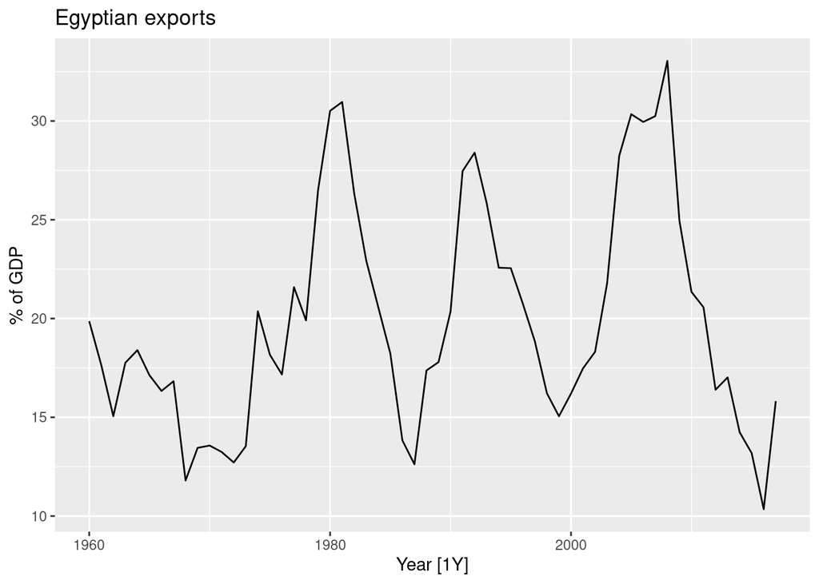

```r
global_economy %>%
  filter(Code == "EGY") %>%
  autoplot(Exports) +
  labs(y = "% of GDP", title = "Egyptian exports")
```

```r
fit <- global_economy %>%
  filter(Code == "EGY") %>%
  model(autoARIMA = ARIMA(Exports))
report(fit)
```

```
Series: Exports
Model: ARIMA(2,0,1) w/ mean

Coefficients:
         ar1      ar2      ma1  constant
      1.6764  -0.8034  -0.6896    2.5623
s.e.  0.1111   0.0928   0.1492    0.1161

sigma^2 estimated as 8.046:  log likelihood=-141.57
AIC=293.13   AICc=294.29   BIC=303.43
```

We can see that these constants satisfy the constraint required for cyclicity $\phi_1^2+4\phi_2=1.68^2-4*0.8<0$, so cyclicity was also correctly identified as part of the features of the data.

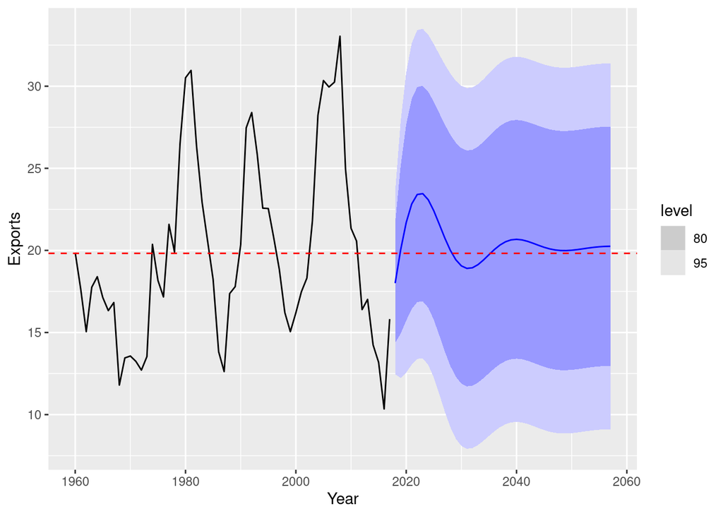

```r
c <- fit %>% tidy() %>% filter(term == "constant") %>% pull(estimate)

mean <- global_economy %>%
  filter(Code == "EGY") %>% pull(Exports) %>% mean()


fit %>%
  forecast(h=40) %>% autoplot(global_economy) +
  geom_hline(yintercept = mean, linetype="dashed", color = "red")
```

# General workflow to build non-seasonal ARIMA models

The chart below (ref. 1) is an excellent summary of how to fit an ARIMA model **to non-seasonal data:**

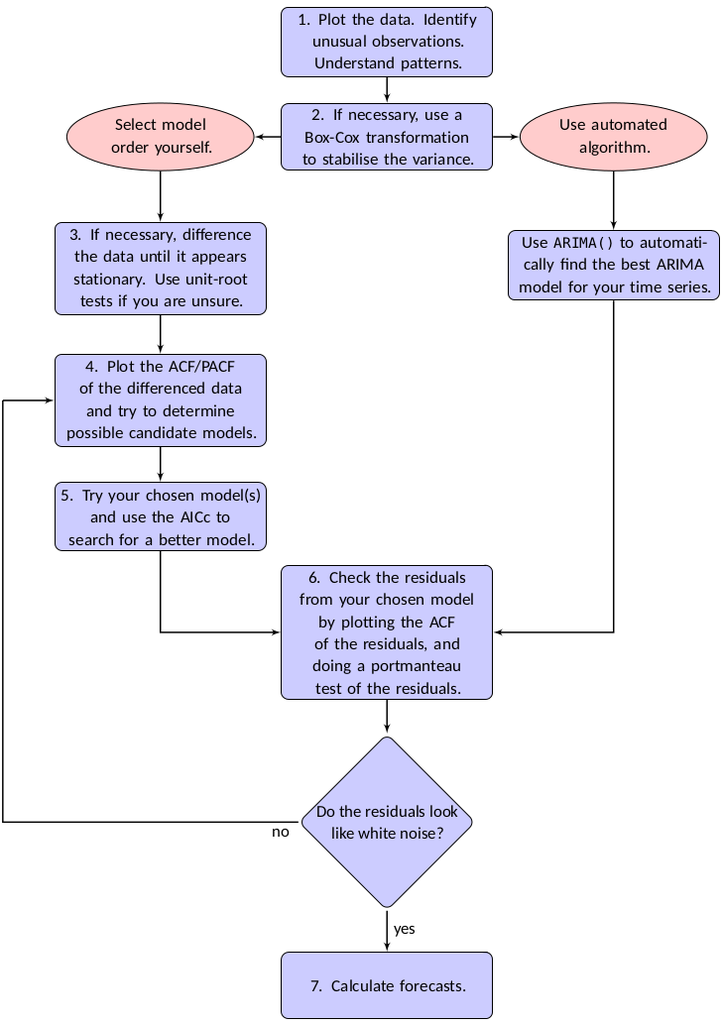

Let us explain in detail the left branch of the diagram, which corresponds to manually identifying the orders of the model:

## Steps 1 to 3 inspect the series and render it stationary

- **Step 1:** first step always when working with data.
- **Step 2:** inspect whether a Box-Cox transformation is necessary to stabilize the variance. This is aimed at **rendering the series variance-stationary**.
- **Step 3:** find the necessary order of differencing $d$ to render the data **trend-stationary**

## Step 4: plot ACF and PACF of the stationary model to find $p$ and $q$

The result of step 3 is a stationary series. As such, this can be modelled using an ARMA process and its ACF and PACF can be interpreted using the rules given in the notebook about ARMA models.

The output of this step is the identification of the orders $p$ and $q$ for one or more candidate models.

## Step 5: fit your candidate models and use AICc to search for the best model

## Step 6: check the residuals of your model

This is particularly important for ARIMA models because the computation of the prediction intervals is strongly dependent on the assumptions that residuals are:

1. Uncorrelated.
2. Normally distributed.

If **residuals are uncorrelated but not normally distributed**, then **bootstrapped intervals can be obtained instead**, as discussed in Section 5.5. This is easily achieved by setting `bootstrap=TRUE` in the `forecast()` function.

**NOTE ON ARIMA PREDICTION INTERVALS (already mentioned)**

- ARIMA models with $d=0$ have prediction intervals that converge in width in the long term (long-term all prediction intervals will have the same width)
- ARIMA models with $d\geq1$ the prediction intervals will continue to grow into the future.

If the model does not satisfy the assumptions, go back to step 4 and try values around the initial orders you identified for $p$ and $q$ until you achieve normally distributed, uncorrelated residuals.

## Step 7: Compute forecasts

# Example: Central African Republic Exports

## Step 1:

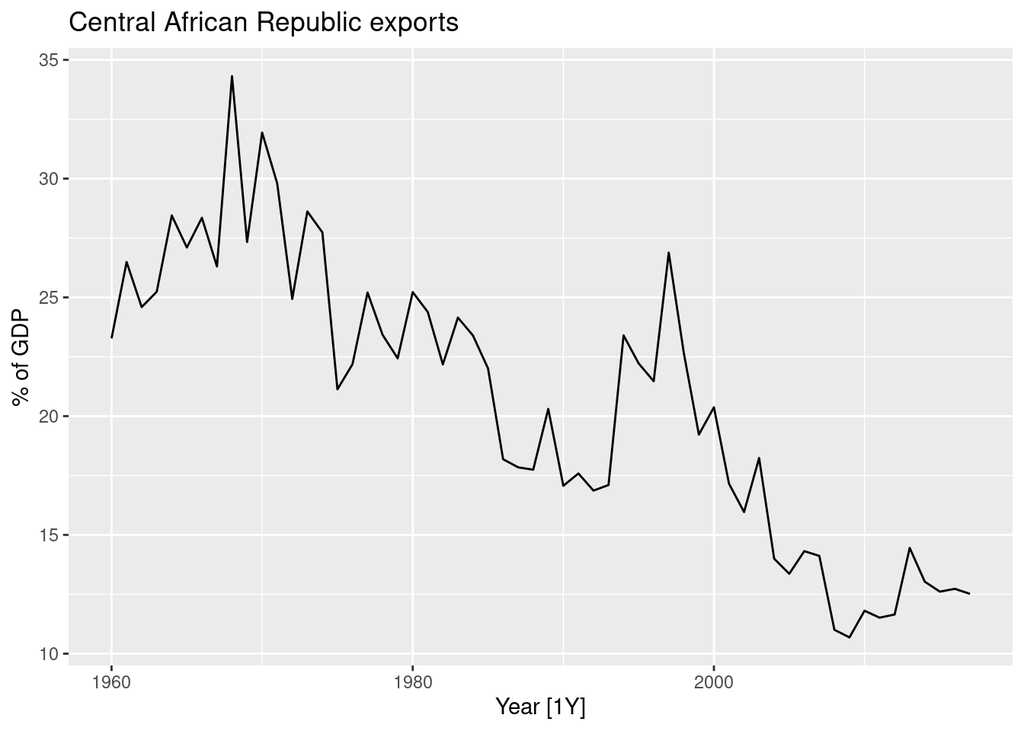

```r
global_economy %>%
  filter(Code == "CAF") %>%
  autoplot(Exports) +
  labs(title="Central African Republic exports",
       y="% of GDP")
```

Data is non-seasonal with a trend that renders it non-stationary.

## Step 2: Check if there is a need for a variance-stabilizing transformation

Variance does not change with the level of the series, so we will not perform a Box-Cox transformation.

## Step 3: Non-stationarity

Let us check if a first-order diffencing does away with the trend-stationarity present in the data:

```r
cafr_exports <-
  global_economy %>%
  filter(Code == "CAF") %>%
  mutate(
    exp_diff = difference(Exports, 1)
  )

cafr_exports %>%
  features(exp_diff, unitroot_kpss)
```

```
# A tibble: 1 × 3
  Country                  kpss_stat kpss_pvalue
  <fct>                        <dbl>       <dbl>
1 Central African Republic    0.0922         0.1
```

In this case $p>0.1$ and, as a result, we fail to reject the null hypothesis that the differenced data is stationary. We therefore confirm the stationarity of the differenced series

## Step 4: plot the ACF/PACF of the stationary data and determine $p$ and $q$

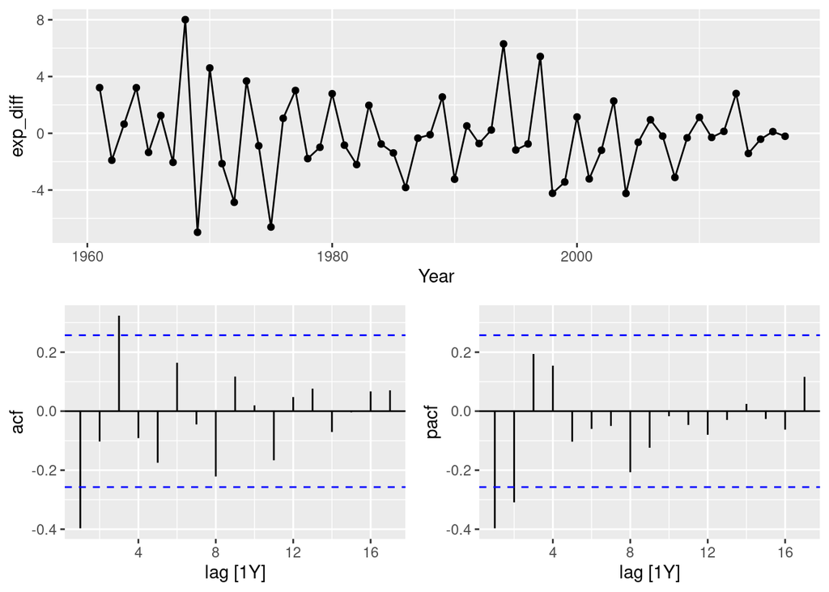

```r
cafr_exports %>%
  gg_tsdisplay(exp_diff, plot_type='partial')
```

Both of them seem to be cutting-off. In this case, we will fit two models:

1. Model suggested by the cut-off of ACF: $MA(3)$
2. Model suggested by the cut-off of PACF: $AR(2)$

Combining both $d$ with these $p$ and $q$ we obtain the following two candidate models:

1. $ARIMA(0, 1, 3)$
2. $ARIMA(2, 1, 0)$

## Step 5: try the models chosen and use AICc to identify the best candidate model

We are going to fit the two models we identified from the inspection of ACF and PACF along with an automatically fitted model.

```r
caf_fit <-
  cafr_exports %>%
  model(
        # Model identified from cut-off of PACF
        arima210 = ARIMA(Exports ~ pdq(2,1,0)),
        # Model identified from cut-off of ACF
        arima013 = ARIMA(Exports ~ pdq(0,1,3)),
        # Automatically fitted model
        stepwise = ARIMA(Exports),
        # Automatically fitted model
        search = ARIMA(Exports, stepwise=FALSE)
        )

glance(caf_fit) %>% arrange(AICc) %>% select(.model:BIC)
```

```
# A tibble: 4 × 6
  .model   sigma2 log_lik   AIC  AICc   BIC
  <chr>     <dbl>   <dbl> <dbl> <dbl> <dbl>
1 search     6.52   -133.  274.  275.  282.
2 arima210   6.71   -134.  275.  275.  281.
3 arima013   6.54   -133.  274.  275.  282.
4 stepwise   6.42   -132.  274.  275.  284.
```

The models we selected using the orders indicated by the ACF and PACF (ARIMA(2,1,0) and ARIMA(0,1,3)) actually beat the simple searched performed by `ARIMA()` in terms of AICc. If we however tell `ARIMA()` to perform a more thorough search by specifying `stepwise=FALSE`, then a slightly better model in terms of AICc is found.

Lets inspect this model:

```r
caf_fit %>% select(search) %>% report()
```

```
Series: Exports
Model: ARIMA(3,1,0)

Coefficients:
          ar1      ar2     ar3
      -0.4419  -0.1850  0.2055
s.e.   0.1295   0.1385  0.1274

sigma^2 estimated as 6.519:  log likelihood=-133
AIC=274   AICc=274.77   BIC=282.18
```

The model increases the order of the autoregressive part of the model compared to our ARIMA(2,1,0)

## Step 6: Inspect residuals

Lets inspect the residuals of the ARIMA(2,1,0) model hinted by the PACF, the ARIMA(0,1,3) model hinted by the ACF and the model with the smallest AICc found by a thorough search by the `ARIMA()` function (ARIMA(3,1,0)):

### ARIMA(2,1,0) residuals

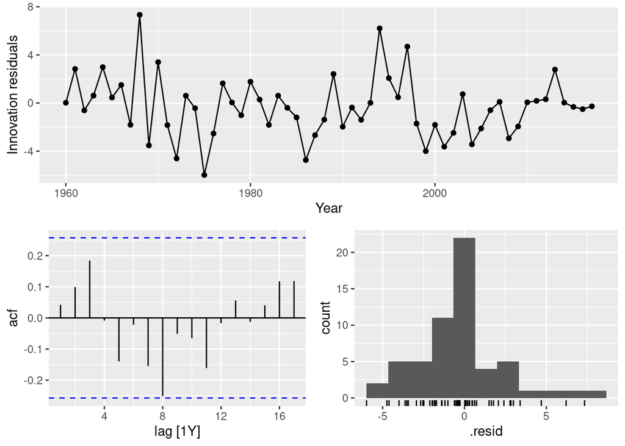

```r
caf_fit %>% select(arima210) %>% gg_tsresiduals()
```

```r
residuals <- caf_fit %>% augment()
residuals_arima210 <- residuals %>% filter(.model == "arima210")

residuals_arima210 %>% pull(.innov) %>% shapiro.test()
```

```
    Shapiro-Wilk normality test

data:  .
W = 0.96903, p-value = 0.1441
```

```r
residuals_arima210 %>% pull(.innov) %>% ks.test("pnorm")
```

```
    Exact one-sample Kolmogorov-Smirnov test

data:  .
D = 0.28401, p-value = 0.000124
alternative hypothesis: two-sided
```

The Shapiro test confirms that the data is normally distributed (fail to reject null) while the Kolmogrov test rejects the normality.

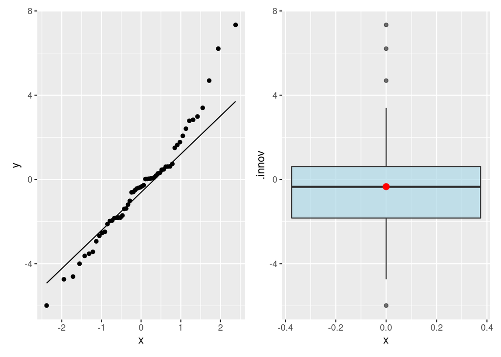

```r
# Generate qq_plot
p1 <- ggplot(residuals_arima210, aes(sample = .innov))
p1 <- p1 + stat_qq() + stat_qq_line()

# Generate box-plot
p2 <- ggplot(data = residuals_arima210, aes(y = .innov)) +
      geom_boxplot(fill="light blue", alpha = 0.7) +
      stat_summary(aes(x=0), fun="mean", colour= "red") # Include the mean

p1 + p2
```

### ARIMA(3,1,0) residuals

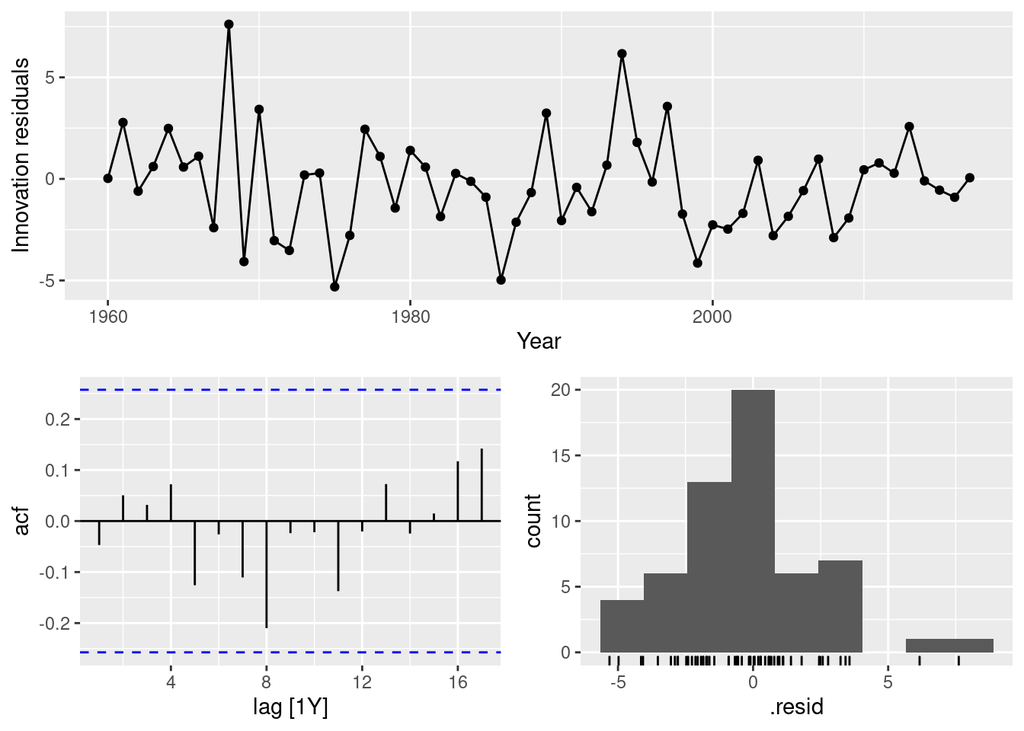

```r
caf_fit %>% select(search) %>% gg_tsresiduals()
```

```r
residuals_search <- residuals %>% filter(.model == "search")

residuals_search %>% pull(.innov) %>% shapiro.test()
```

```
    Shapiro-Wilk normality test

data:  .
W = 0.96967, p-value = 0.1545
```

```r
residuals_search %>% pull(.innov) %>% ks.test("pnorm")
```

```
    Exact one-sample Kolmogorov-Smirnov test

data:  .
D = 0.29179, p-value = 7.198e-05
alternative hypothesis: two-sided
```

Again the Shapiro-Wilk test fails to reject the normality assumption, while the Kolmogorov-Smirnov test rejects it.

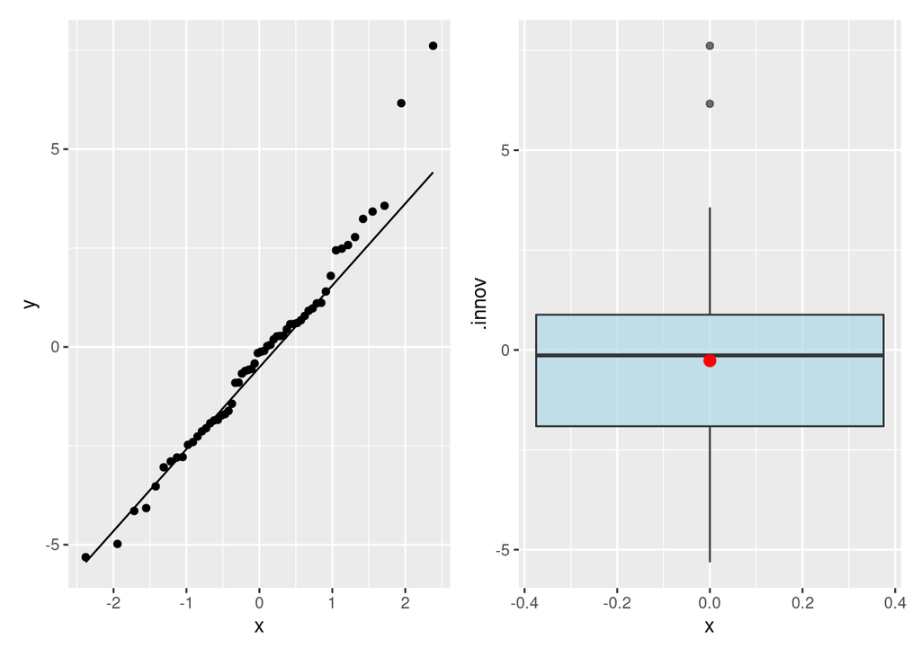

```r
# Generate qq_plot
p1 <- ggplot(residuals_search, aes(sample = .innov))
p1 <- p1 + stat_qq() + stat_qq_line()

# Generate box-plot
p2 <- ggplot(data = residuals_search, aes(y = .innov)) +
      geom_boxplot(fill="light blue", alpha = 0.7) +
      stat_summary(aes(x=0), fun="mean", colour= "red") # Include the mean

p1 + p2
```

### ARIMA(0,1,3) residuals

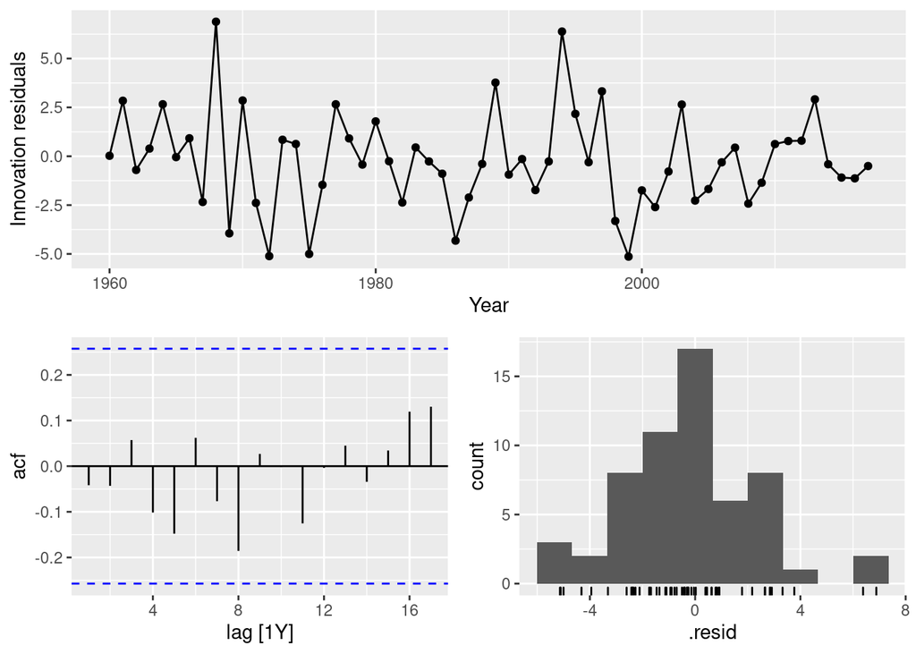

```r
caf_fit %>% select(arima013) %>% gg_tsresiduals()
```

```r
residuals_arima013 <- residuals %>% filter(.model == "arima013")

residuals_arima013 %>% pull(.innov) %>% shapiro.test()
```

```
    Shapiro-Wilk normality test

data:  .
W = 0.96754, p-value = 0.1224
```

```r
residuals_arima013 %>% pull(.innov) %>% ks.test("pnorm")
```

```
    Exact one-sample Kolmogorov-Smirnov test

data:  .
D = 0.22928, p-value = 0.003665
alternative hypothesis: two-sided
```

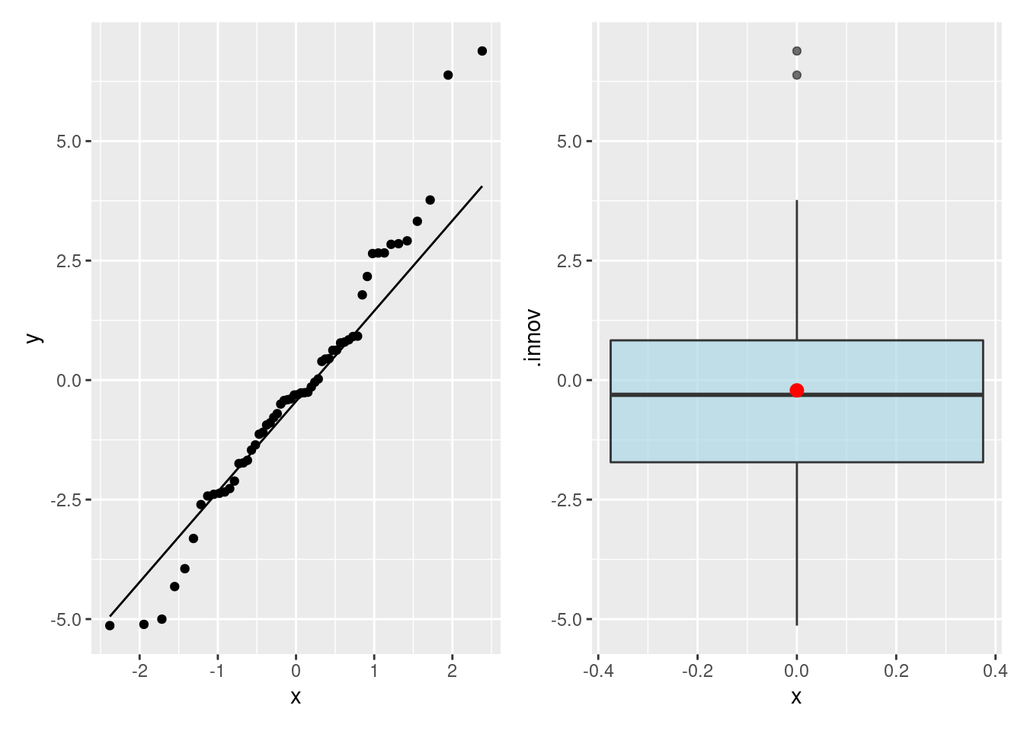

```r
# Generate qq_plot
p1 <- ggplot(residuals_arima013, aes(sample = .innov))
p1 <- p1 + stat_qq() + stat_qq_line()

# Generate box-plot
p2 <- ggplot(data = residuals_arima013, aes(y = .innov)) +
      geom_boxplot(fill="light blue", alpha = 0.7) +
      stat_summary(aes(x=0), fun="mean", colour= "red") # Include the mean

p1 + p2
```

## Step 6: additional - inspect the unit roots

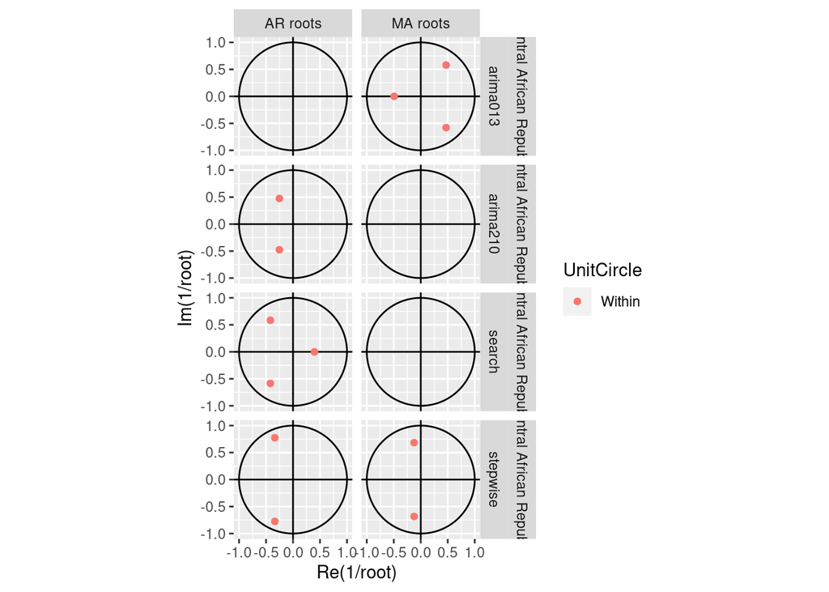

```r
caf_fit %>% gg_arma()
```

Of the four models fitted only the model that was auomatically fitted using the fast version of the algorithm seems to exhibit two AR roots that perhaps could lead to numerical instabilities (the two AR roots close to the unit circle).

## Step 7: choose a model

In this case all of our models pass only the Shapiro-test and fail the Kolmogrov-smirnov test. Among the proposed models, the qq-plot of the ARIMA(3,1,0) model seems the closest to normal. Hence, this model seems the most sensible among those that were fitted.

In a real-case scenario, we would also perform cross-validation to confirm if this is the model that leads to the smallest errors consistently on the available data. Here we will skip this to keep the notebook leaner.

Let us depict the forecasts of the ARIMA(3,1,0) model

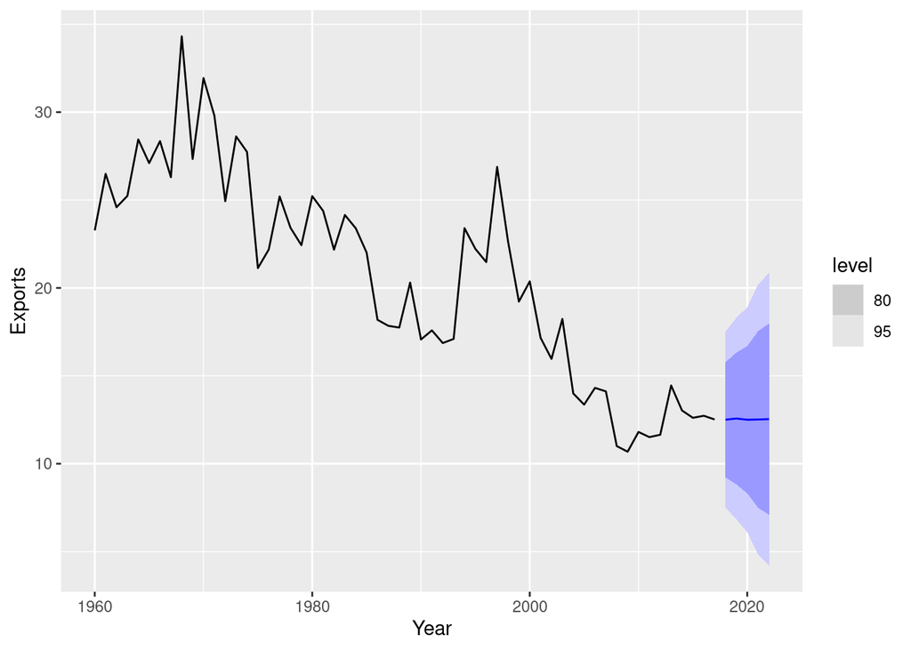

```r
caf_fit %>%
  forecast(h=5) %>%
  filter(.model=='search') %>%
  autoplot(global_economy)
```